# assignment

# Feature scaling

```r
data.pre <- preProcess(trainData, method = "range")
trainData_scaled <- predict(data.pre, trainData)
testData_scaled <- predict(data.pre, testData)

# Append the target variable back to the scaled datasets
trainData_scaled$Class <- trainData$Class
testData_scaled$Class <- testData$Class
```

#Task4: Train Models : we are using Decision Tree, Naive Bayes,Bagging Model,xgboost,Random Forest for Training

```r
library(rpart)

# Train a Decision Tree model
trainData_scaled$Class <- factor(trainData_scaled$Class)
tree <- rpart(Class ~ ., trainData_scaled)

# Train a Naive Bayes model
naive_bayes_model <- naiveBayes(Class ~ ., data = trainData_scaled)

# Train a Bagging model
bagging_model <- bagging(Class ~ ., data = trainData_scaled, nbagg = 25)


library(xgboost)
# Train an XGBoost model
xgb_train <- xgb.DMatrix(data = as.matrix(trainData_scaled[-ncol(trainData_scaled)]), label = as.numeric(trainData_scaled$Class) - 1)
xgb_test <- xgb.DMatrix(data = as.matrix(testData_scaled[-ncol(testData_scaled)]), label = as.numeric(testData_scaled$Class) - 1)
xgb_params <- list(
  booster = "gbtree",
  eta = 0.01,
  max_depth = 8,
  gamma = 4,
  subsample = 0.75,
  colsample_bytree = 1,
  objective = "binary:logistic",
  eval_metric = "logloss"
)
xgb_model <- xgb.train(
  params = xgb_params,
  data = xgb_train,
  nrounds = 5000,
  verbose = 1
)
xgb_model
```

```
## ##### xgb.Booster
## raw: 16.1 Mb
## call:
##   xgb.train(params = xgb_params, data = xgb_train, nrounds = 5000,
##     verbose = 1)
## params (as set within xgb.train):
##   booster = "gbtree", eta = "0.01", max_depth = "8", gamma = "4", subsample = "0.75", colsample_bytree = "1", objective = "binary:logistic", eval_metric = "logloss", validate_parameters = "TRUE"
## xgb.attributes:
##   niter
## callbacks:
##   cb.print.evaluation(period = print_every_n)
## # of features: 16
## niter: 5000
## nfeatures : 16
```

```r
library(randomForest)
# Train a Random Forest model
random_forest_model = randomForest(x = trainData_scaled[-17],
                          y = trainData_scaled$Class,
                          ntree = 500, random_state = 42)
```

#Task 5: Make Predictions

```r
# Predict using the Decision Tree model
dt_pred <- predict(tree, testData_scaled, type = "class")

# Predict using the Naive Bayes model
nb_pred <- predict(naive_bayes_model, newdata = testData_scaled)

# Predict using the Bagging model
bagging_pred <- predict(bagging_model, newdata = testData_scaled)


# Predict using the XGBoost model
xgb_pred_prob <- predict(xgb_model, newdata = xgb_test)
xgb_pred <- ifelse(xgb_pred_prob > 0.5, 1, 0)


# Predict using the Random Forest model

rf_pred <- predict(random_forest_model, newdata = testData_scaled[-17], type = "class")
```

### Convert Predictions to Factors

```r
testData_scaled$Class <- as.factor(testData_scaled$Class)
levels(testData_scaled$Class) <- c("0", "1")

dt_pred <- as.factor(dt_pred)
levels(dt_pred) <- c("0", "1")

nb_pred <- as.factor(nb_pred)
levels(nb_pred) <- c("0", "1")

bagging_pred <- as.factor(bagging_pred)
levels(bagging_pred) <- c("0", "1")

xgb_pred <- as.factor(xgb_pred)
levels(xgb_pred) <- c("0", "1")

rf_pred <- as.factor(rf_pred)
levels(rf_pred) <- c("0", "1")
```

### Confusion Matrix and Accuracy

```r
# Decision Tree
dt_conf_matrix <- confusionMatrix(dt_pred, testData_scaled$Class)
dt_accuracy <- dt_conf_matrix$overall['Accuracy']

# Naive Bayes
nb_conf_matrix <- confusionMatrix(nb_pred, testData_scaled$Class)
nb_accuracy <- nb_conf_matrix$overall['Accuracy']

# Bagging
bagging_conf_matrix <- confusionMatrix(bagging_pred, testData_scaled$Class)
bagging_accuracy <- bagging_conf_matrix$overall['Accuracy']

# XGBoost
xgb_conf_matrix <- confusionMatrix(xgb_pred, testData_scaled$Class)
xgb_accuracy <- xgb_conf_matrix$overall['Accuracy']


# Random Forest
rf_conf_matrix <- confusionMatrix(rf_pred, testData_scaled$Class)
rf_accuracy <- rf_conf_matrix$overall['Accuracy']
```

### ROC Curves and AUC

[figure not shown]

```r
# Calculate probabilities
dt_prob <- predict(tree, newdata = testData_scaled, type = "prob")[,2]
nb_prob <- predict(naive_bayes_model, newdata = testData_scaled, type = "raw")[,2]
bagging_prob <- predict(bagging_model, newdata = testData_scaled, type = "prob")[,2]
rf_prob <- predict(random_forest_model, newdata = testData_scaled, type = "prob")[,2]
xgb_prob <- xgb_pred_prob


# ROC Curves and AUC
#roc
roc_dt <- roc(testData_scaled$Class, dt_prob)
roc_nb <- roc(testData_scaled$Class, nb_prob)
roc_bagging <- roc(testData_scaled$Class, bagging_prob)
#roc_boosting <- roc(testData_scaled$Class, boosting_prob)
roc_rf <- roc(testData_scaled$Class, rf_prob)
roc_xgb <- roc(testData_scaled$Class, as.numeric(xgb_prob))
#auc
auc_dt <- auc(roc_dt)
auc_nb <- auc(roc_nb)
auc_bagging <- auc(roc_bagging)
#auc_boosting <- auc(roc_boosting)
auc_rf <- auc(roc_rf)
auc_xgb <- auc(roc_xgb)

# Plot ROC Curves
plot(roc_dt, col = "red", main = "ROC Curves")
plot(roc_nb, col = "blue", add = TRUE)
plot(roc_bagging, col = "green", add = TRUE)
#plot(roc_boosting, col = "purple", add = TRUE)
plot(roc_rf, col = "orange", add = TRUE)
plot(roc_xgb, col = "brown", add = TRUE)
legend("bottomright", legend = c("Decision Tree", "Naive Bayes", "Bagging",  "Random Forest", "XGBoost"), col = c("red", "blue", "purple", "orange", "brown"), lwd = 2)
```

#Task 7: Comparsion Table:

```r
comparison_table <- data.frame(
  Model = c("Decision Tree", "Naive Bayes", "Bagging", "Random Forest", "XGBoost"),
  Accuracy = c(dt_accuracy, nb_accuracy, bagging_accuracy, rf_accuracy, xgb_accuracy),
  AUC = c(auc_dt, auc_nb, auc_bagging, auc_rf, auc_xgb)
)

print(comparison_table)
```

```
##           Model  Accuracy       AUC
## 1 Decision Tree 0.7750000 0.7787472
## 2   Naive Bayes 0.7066667 0.7363569
## 3       Bagging 0.7716667 0.8066737
## 4 Random Forest 0.8033333 0.8245134
## 5       XGBoost 0.7883333 0.8200433
```

```r
# Determine the best classifier based on Accuracy
best_classifier <- comparison_table[which.max(comparison_table$Accuracy),]
print(best_classifier)
```

```
##           Model  Accuracy       AUC
## 4 Random Forest 0.8033333 0.8245134
```

# So, we have best model Random Forest having 80.33% of accuracy and Auc of 82.4%

#task 8:

```r
# Random Forest feature importance
rf_importance <- importance(random_forest_model)
rf_importance_df <- data.frame(Variable = rownames(rf_importance), Importance = rf_importance[, 1])
rf_importance_df <- rf_importance_df[order(-rf_importance_df$Importance), ]

# XGBoost feature importance
xgb_importance <- xgb.importance(model = xgb_model)
xgb_importance_df <- as.data.frame(xgb_importance)
xgb_importance_df <- xgb_importance_df[order(-xgb_importance_df$Gain), ]

# Combine and compare importance
combined_importance <- merge(rf_importance_df, xgb_importance_df, by.x = "Variable", by.y = "Feature", all = TRUE)
combined_importance <- combined_importance[order(-combined_importance$Importance), ]

print("Combined Feature Importance:")
```

```
## [1] "Combined Feature Importance:"
```

```r
print(combined_importance)
```

```
##    Variable  Importance        Gain      Cover   Frequency
## 1       A01 134.5664315 0.221110557 0.15908939 0.122778675
## 14      A23 104.3999472 0.240806691 0.14490424 0.149307032
## 13      A22  95.4838928 0.179962198 0.20232918 0.242156279
## 10      A18  92.2761111 0.127467150 0.14819042 0.159510246
## 6       A08  47.5656640 0.077633990 0.10759745 0.102542301
## 15      A24  33.4072740 0.038428252 0.05239901 0.059518748
## 7       A12  31.6735483 0.040453855 0.06374637 0.066831052
## 8       A14  23.1490889 0.024195677 0.02760764 0.018195732
## 12      A20  15.0034624 0.014415689 0.02276931 0.017090383
## 9       A17  13.9131102 0.010640978 0.01717270 0.018110705
## 3       A04  10.4845937 0.007722602 0.01032325 0.011393589
## 2       A02   9.6814630 0.010814062 0.02874605 0.019811241
## 4       A06   7.6127130 0.004682231 0.01236085 0.009523000
## 11      A19   6.8552858 0.001666068 0.00276413 0.003231018
## 5       A07   1.0116396          NA         NA          NA
## 16      A25   0.9761198          NA         NA          NA
```

```r
# Identify least important features
least_important_rf <- tail(rf_importance_df, 5)
least_important_xgb <- tail(xgb_importance_df, 5)

print("Least Important Features in Random Forest:")
```

```
## [1] "Least Important Features in Random Forest:"
```

```r
print(least_important_rf)
```

```
##     Variable Importance
## A02      A02  9.6814630
## A06      A06  7.6127130
## A19      A19  6.8552858
## A07      A07  1.0116396
## A25      A25  0.9761198
```

```r
print("Least Important Features in XGBoost:")
```

```
## [1] "Least Important Features in XGBoost:"
```

```r
print(least_important_xgb)
```

```
##    Feature        Gain      Cover   Frequency
## 10     A02 0.010814062 0.02874605 0.019811241
## 11     A17 0.010640978 0.01717270 0.018110705
## 12     A04 0.007722602 0.01032325 0.011393589
## 13     A06 0.004682231 0.01236085 0.009523000
## 14     A19 0.001666068 0.00276413 0.003231018
```

# Conclusion:

Features to Consider for Omission: A02: Identified as low importance in both Random Forest and XGBoost. A06: Identified as low importance in both Random Forest and XGBoost. A19: Identified as low importance in both Random Forest and XGBoost. A07: Identified as low importance in Random Forest. A25: Identified as low importance in Random Forest. A17: Identified as low importance in XGBoost. A04: Identified as low importance in XGBoost. So, we can remove or not consider these features for Building our model.

#task:9

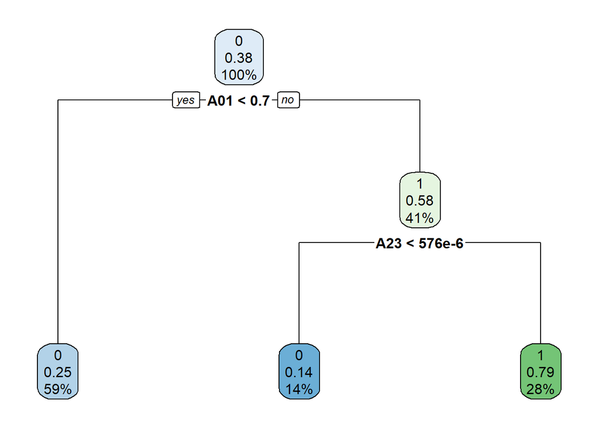

```r
library(rpart.plot)
# Create a simple Decision Tree model
simple_tree_model <- rpart(Class ~ ., data = trainData_scaled, control = rpart.control(maxdepth = 2))
rpart.plot(simple_tree_model)
```

```r
# Predict using the simple tree model
simple_tree_pred <- predict(simple_tree_model, newdata = testData_scaled, type = "class")

# Evaluate performance
simple_tree_conf_matrix <- confusionMatrix(simple_tree_pred, testData_scaled$Class)
simple_tree_accuracy <- simple_tree_conf_matrix$overall['Accuracy']
simple_tree_roc <- roc(testData_scaled$Class, as.numeric(predict(simple_tree_model, newdata = testData_scaled)[, 2]))
simple_tree_auc <- auc(simple_tree_roc)

print(paste("Simple Tree Accuracy:", simple_tree_accuracy))
```

```
## [1] "Simple Tree Accuracy: 0.768333333333333"
```

```r
print(paste("Simple Tree AUC:", simple_tree_auc))
```

```
## [1] "Simple Tree AUC: 0.753183786552431"
```

```r
# Compare with other models
comparison_table <- rbind(comparison_table, data.frame(
  Model = "Simple Tree",
  Accuracy = simple_tree_accuracy,
  AUC = simple_tree_auc
))

print(comparison_table)
```

```
##                  Model  Accuracy       AUC
## 1        Decision Tree 0.7750000 0.7787472
## 2          Naive Bayes 0.7066667 0.7363569
## 3              Bagging 0.7716667 0.8066737
## 4        Random Forest 0.8033333 0.8245134
## 5              XGBoost 0.7883333 0.8200433
## Accuracy   Simple Tree 0.7683333 0.7531838
```

```r
# Cross-validation and parameter tuning for Random Forest
control <- trainControl(method = "cv", number = 5)
tunegrid <- expand.grid(.mtry = c(2, 4, 6, 8, 10))

set.seed(100000)
rf_optimized <- train(Class ~ ., data = trainData_scaled, method = "rf", trControl = control, tuneGrid = tunegrid)

# Get the best model
best_rf_model <- rf_optimized$finalModel

# Predict using the optimized Random Forest model
best_rf_pred <- predict(best_rf_model, newdata = testData_scaled)

# Evaluate performance
best_rf_conf_matrix <- confusionMatrix(best_rf_pred, testData_scaled$Class)
best_rf_accuracy <- best_rf_conf_matrix$overall['Accuracy']
best_rf_roc <- roc(testData_scaled$Class, as.numeric(predict(best_rf_model, newdata = testData_scaled, type = "prob")[, 2]))
best_rf_auc <- auc(best_rf_roc)

print(paste("Optimized Random Forest Accuracy:", best_rf_accuracy))
```

```
## [1] "Optimized Random Forest Accuracy: 0.806666666666667"
```

```r
print(paste("Optimized Random Forest AUC:", best_rf_auc))
```

```
## [1] "Optimized Random Forest AUC: 0.817505587632706"
```

```r
# Compare with other models
comparison_table <- rbind(comparison_table, data.frame(
  Model = "Optimized Random Forest",
  Accuracy = best_rf_accuracy,
  AUC = best_rf_auc
))

print(comparison_table)
```

```
##                             Model  Accuracy       AUC
## 1                   Decision Tree 0.7750000 0.7787472
## 2                     Naive Bayes 0.7066667 0.7363569
## 3                         Bagging 0.7716667 0.8066737
## 4                   Random Forest 0.8033333 0.8245134
## 5                         XGBoost 0.7883333 0.8200433
## Accuracy              Simple Tree 0.7683333 0.7531838
## Accuracy1 Optimized Random Forest 0.8066667 0.8175056
```

#Conclusion: The Simple Decision Tree model offers a terrific stability between interpretability and performance, making it a suitable desire for guide category obligations while remaining aggressive with extra complicated models.

#Task:11 Implement an Artificial Neural Network (ANN) Classifier

```r
library(nnet)
# Install caret package if not already installed
if (!requireNamespace("caret", quietly = TRUE)) {
  install.packages("caret")
}

# Load caret package
library(caret)


# Convert the target variable to a factor
trainData_scaled$Class <- as.factor(trainData_scaled$Class)
testData_scaled$Class <- as.factor(testData_scaled$Class)

# Train the ANN model
set.seed(100000)
ann_model <- nnet(Class ~ ., data = trainData_scaled, size = 10, maxit = 200, linout = FALSE)
# Predict using the ANN model
ann_pred_prob <- predict(ann_model, newdata = testData_scaled, type = "raw")
ann_pred <- ifelse(ann_pred_prob > 0.5, 1, 0)

# Evaluate performance
ann_conf_matrix <- confusionMatrix(as.factor(ann_pred), testData_scaled$Class)
ann_accuracy <- ann_conf_matrix$overall['Accuracy']
ann_roc <- roc(testData_scaled$Class, as.numeric(ann_pred_prob))
ann_auc <- auc(ann_roc)

print(paste("ANN Accuracy:", ann_accuracy))
```

```
## [1] "ANN Accuracy: 0.705"
```

```r
print(paste("ANN AUC:", ann_auc))
```

```
## [1] "ANN AUC: 0.713005215123859"
```

```r
# Compare with other models
comparison_table <- rbind(comparison_table, data.frame(
  Model = "ANN",
  Accuracy = ann_accuracy,
  AUC = ann_auc
))

print(comparison_table)
```

```
##                             Model  Accuracy       AUC
## 1                   Decision Tree 0.7750000 0.7787472
## 2                     Naive Bayes 0.7066667 0.7363569
## 3                         Bagging 0.7716667 0.8066737
## 4                   Random Forest 0.8033333 0.8245134
## 5                         XGBoost 0.7883333 0.8200433
## Accuracy              Simple Tree 0.7683333 0.7531838
## Accuracy1 Optimized Random Forest 0.8066667 0.8175056
## Accuracy2                     ANN 0.7050000 0.7130052
```

#Analysis: The ANN classifier done an accuracy of 0.7050 and an AUC of 0.7130. These results are decrease than the ones of the Random Forest and XGBoost models. The complexity and intensity of the neural community version won’t be completely utilized given the dimensions and nature of the dataset. Additionally, neural networks normally require more statistics to gain better overall performance, that could give an explanation for why less complicated models carried out higher in this example. Moreover, the ANN might need tunning and a more big hyperparameter tunning to improve its performance.

#Task 12: Implement a New Classifier (Support Vector Machine with Radial Basis Function Kernel) # Data Preprocessing : It will be same as prev models

```r
# Install and load required packages
if (!requireNamespace("e1071", quietly = TRUE)) {
  install.packages("e1071")
}

library(e1071)
# Ensure the caret package is installed and loaded
if (!requireNamespace("caret", quietly = TRUE)) {
  install.packages("caret")
}



# Train the SVM model with RBF kernel
set.seed(100000)
# Load necessary library
library(e1071)

# Define and train the SVM model
svm_model <- svm(Class ~ ., data = trainData_scaled, probability = TRUE)

# Predict using the SVM model
svm_pred <- predict(svm_model, newdata = testData_scaled, probability = TRUE)
svm_prob <- attr(svm_pred, "probabilities")[, 2]

# Calculate performance metrics
svm_conf_matrix <- confusionMatrix(as.factor(svm_pred), as.factor(testData_scaled$Class))
svm_roc <- roc(testData_scaled$Class, svm_prob)
svm_auc <- auc(svm_roc)

# Print results
svm_accuracy <- svm_conf_matrix$overall['Accuracy']
print(paste("SVM Accuracy:", svm_accuracy))
```

```
## [1] "SVM Accuracy: 0.776666666666667"
```

```r
print(paste("SVM AUC:", svm_auc))
```

```
## [1] "SVM AUC: 0.80007333767927"
```

```r
# Compare with other models
comparison_table <- rbind(comparison_table, data.frame(
  Model = "SVM",
  Accuracy = svm_accuracy,
  AUC = svm_auc
))

print(comparison_table)
```

```
##                             Model  Accuracy       AUC
## 1                   Decision Tree 0.7750000 0.7787472
## 2                     Naive Bayes 0.7066667 0.7363569
## 3                         Bagging 0.7716667 0.8066737
## 4                   Random Forest 0.8033333 0.8245134
## 5                         XGBoost 0.7883333 0.8200433
## Accuracy              Simple Tree 0.7683333 0.7531838
## Accuracy1 Optimized Random Forest 0.8066667 0.8175056
## Accuracy2                     ANN 0.7050000 0.7130052
## Accuracy3                     SVM 0.7766667 0.8000733
```

#Conclusion: The SVM classifier carried out an accuracy of zero.7767 and an AUC of 0.8001. While the SVM performed better than some Models like Naive Bayes and ANN, it did no longer surpass the performance of Random Forest, Optimized Random Forest, or XGBoost in terms of accuracy. However, it’s far competitive in phrases of AUC, indicating a great potential to distinguish between phishing and valid sites.

# Description of the SVM Model:

SVm is a robust model,which selects the hyperplane that maximizes the margin between the nearest data points of each class, known as support vectors. It having Kernal which helps in Hyper Parameter tuning to acheive good accuracy. #Final Conclusion: But for this particular Dataset,Optimized Random Forest , and Xgboost is working well.